# Check $F_{is}$ and LD of microsatellite loci

Jenna Melanson

2025-06-20

Ideally, high-quality markers should be in Hardy-Weinberg equilibrium (e.g., inbreeding coefficient $F_{is} = 0$) and should be independently assorted (e.g., no linkage disequilibrium between markers). COLONY 2.0 can account for inbreeding at the population level, if specified, but $F_{is}$ estimates for individual loci which are significantly different from the global mean $F_{is}$ can be indicative of null alleles or other scoring errors.

The distributions of $F_{is}$ estimates for each species at each site are shown below. The blue dotted line indicates $F_{is}$ = 0, and the red dotted lines indicate $F_{is}$ = $\pm$ 0.1.

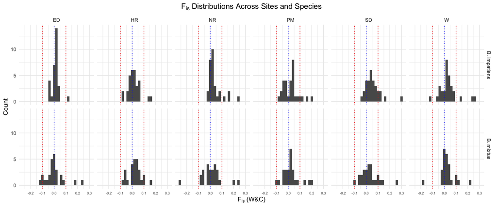

We employed a linear model of $F_{is}$ estimates with locus and site as fixed predictors. We used sum-to-zero coding so that the model intercept represented the global mean $F_{is}$ across loci, and calculated the effect of each locus and site using the *emmeans* package.

Below we show the computed effects of each locus for each species. The dashed black line represents $F_{is} = 0$, and the dashed red line represents the global mean $F_{is}$.

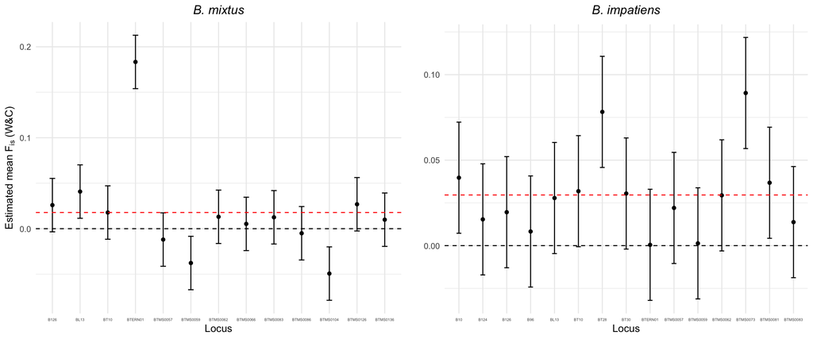

We iteratively removed loci which were significantly different from the global mean, starting with the locus with the greatest deviation, and re-running the model after each removal (i.e., because removing a locus with a high or low inbreeding coefficient will change the global mean and therefore all comparisons to the global mean). We did not apply an adjustment for multiple-hypothesis testing (i.e., comparison of multiple loci to the global mean $F_{is}$) but instead utilized a relatively stringent p-value ($\alpha$ = 0.01) for removal of loci.

This process resulted in the removal of loci BTERN01, BTMS0104, and BTMS0059 from downstream analysis of *B. mixtus* and removal of BTMS0073 and BT28 for *B. impatiens*. $F_{is}$ estimates for the remaining loci (n = 10 for *B. mixtus*, n = 13 for *B. impatiens*) are shown below.

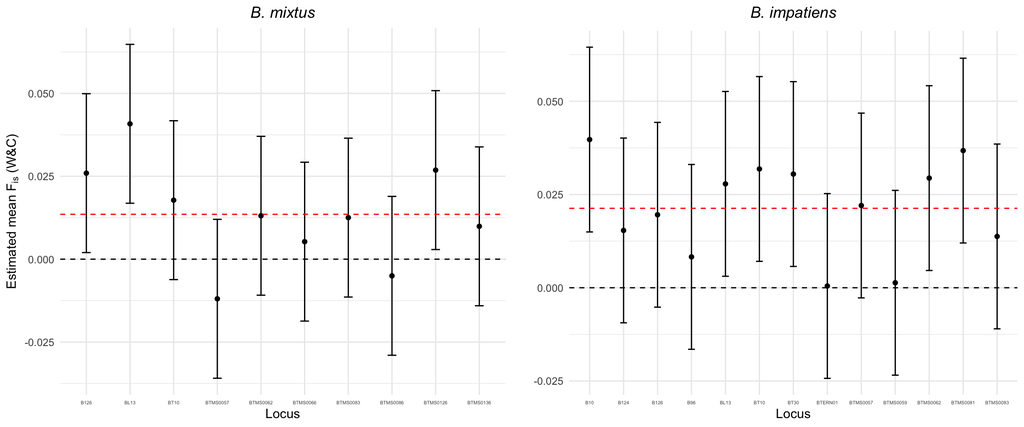

Finally, we checked locus pairs for linkage disequilibrium in GENEPOP. LD values were calculated for each locus pair in each population (site and year). We applied a Bonferroni correction for multiple hypothesis testing, and flagged locus pairs which showed significant deviations in $>2$ populations.

[[**NOTE for Mike**: Is there a better way of approaching this? You suggested that Bonferroni correction wasn’t the best way to approach $F_{is}$ / HWE, and I wonder if similar logic would apply here? It does seem odd to me to correct for multiple hypothesis testing and then only drop loci if they exceed the Bonferroni-correct p-value in *multiple* cases–it’s common practice in the literature, but perhaps it would be better to first assess $F_{st}$ between populations and then test LD of loci across *all* samples rather than individually for each population?]]

After locus quality screening, we calculated global $F_{st}$ between sites to determine whether populations were in panmixia, or whether allele frequencies varied between sites. Moderate or high $F_{st}$ between sites would suggest that final siblingship assignments should be run separately to account for differences in allele frequencies between populations.

For both species and years, global $F_{st} < 0.005$, but to be doubly sure we additionally calculated Weir and Cockerham’s pairwise $F_{st}$ between sites for each species and year.

Pairwise $F_{st}$ ranged from -0.002 to 0.01, again providing no substantial evidence of population differentiation. [[Another note to Mike: I read that Fst can sometimes be negative if between population variance is estimated to be slightly smaller than within population variance, as an artifact of finite sampling, but that this mostly occurs when sample sizes are small or unequal. My sample sizes are unequal but the smallest sample size at a given site is 48. Would you just interpret this as some noise resulting from unequal sample size and round to 0, or should I be concerned?]]

Finally, we computed the effect of site on $F_{is}$ scores to determine whether inbreeding was present at some sites but not others, or in variable amounts.

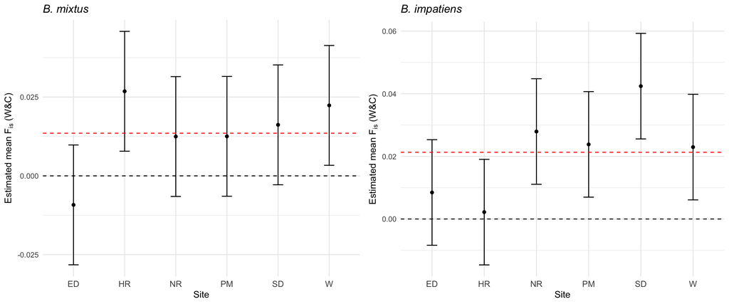

[[Last note for Mike: does this $F_{is}$ or variation in $F_{is}$ seem sufficiently low to you? I think you mentioned that < 0.05 or 0.1 was probably okay to ignore? I also realized that COLONY 2.0 actually *can* handle inbreeding/deviations from HWE, but they state in the user manual that: “When inbreeding is present, a population level (average) inbreeding coefficient, equivalent to Wright’s FIS, is inferred iteratively with other parameters (e.g. relationship, allele frequencies) and is used for calculating genotype frequencies…Note that, for dioecious, the non-inbreeding model is recommended except when there is strong evidence of inbreeding and the inbreeding level is high. Otherwise, using the inbreeding model for data with low or no inbreeding could slow down the computation substantially with little or no improvement for the estimation of relationships.”

My conclusion from this would be that we should NOT ask the software to account for $F_{is}$ in this case, as it’s probably unnecessary.

Given the very low $F_{st}$, **I also wonder whether you think it would be prudent to combine all sites for siblingship assignment (e.g., to improve estimation of allele frequencies by pooling data)**. The alternative would be to run the model 5* times for each population (e.g., 2 species * 2 years * 6 sites = 24 populations). I can run them on a server in parallel so time is not really an issue.

*5 times per population is a technique that I have seen repeatedly in the literature–to avoid ‘spurious siblingships’, like the ones I mentioned to you last time we met. Apparently it’s a common issue with COLONY, and people get around it by performing multiple runs and only maintaining the siblingships with occur with high probability in all of them. I tried it for one of my populations and sure enough all of the between-site siblingships (inviduals > 3km apart!) dropped out!]]